# Analysis of Impact of Military size on Global Peace Index

## Introduction

"The war to end all wars" is a famous term for the First World War of 1914-1918. However, history knows how that turned out. Soon after World War II engulfing entire Eruope in War. When World world II ended and the entire world saw the devastating power of nuclear bomb, some believed that human kind would not bring themselves to destruction and finally peace is about. However, we know from past that this lead to competition in cold war and today continues to threat wolrd peace by countries such as North Korea.

United States spend exorbitant amount of money on military and many believe that that strong military force is the only thing that can detterr conflict. Is this true? We will find out using Global Peace index and various military data such as military expenditure, army personnel count to see how these impact peace index of a country.

## What we'll Accomplish in This tutorial

Thorughout This tutorial we will Process Data such as formatting dataframes as we like and imputing missing values, Make graph visualization of the data, build linear regressions models using dataframe and analyze and make a meaningful conclusion from obtained information.

## Obtaining data and processing

We will use data sets from kaggle and world bank. Dataset from kaggle needs to be downloded manaully from [Here](https://www.kaggle.com/datasets/abhijitdahatonde/global-armed-forces-dataset) , [Here](https://www.kaggle.com/datasets/xenohunter/global-peace-index) , [Here.](https://www.kaggle.com/datasets/zgrcemta/world-gdpgdp-gdp-per-capita-and-annual-growths) And [Here.](https://www.kaggle.com/datasets/nitinsss/military-expenditure-of-countries-19602019) Make sure to download all four as they are different datasets. GDP data set is a zip file with mutliple csv. We will use the gdp.csv  
Rather than manually downloading, you could also use Kaggle API to retrieve them directly but it's much simpler to download manually. If you want to use the kaggle API, read [This](https://saturncloud.io/blog/how-to-import-kaggle-datasets-into-jupyter-notebook/) for Jupyter Notebook. Or [This](https://www.kaggle.com/discussions/general/74235) for Google Colab

```python
import pandas as pd


mil = pd.read_csv('military.csv')
gpi = pd.read_csv('gpi-2008-2019.csv')
gdp = pd.read_csv('gdp.csv')
exp = pd.read_csv('Military Expenditure.csv')

#displaying the dataframes
display(mil)
display(gpi)
display(gdp)
display(exp)
```

|  | SR.NO | Country | Active military | Reserve military | Paramilitary | Total | Per 1,000 capita(active) | Per 1,000 capita(total) |
| --- | --- | --- | --- | --- | --- | --- | --- | --- |
| 0 | 1 | Afghanistan | 250000 | 75000 | 170000 | 495000 | 7.2 | 14.2 |
| 1 | 2 | Albania | 8000 | 0 | 0 | 8000 | 2.6 | 2.6 |
| 2 | 3 | Algeria | 130000 | 150000 | 187200 | 467200 | 3.1 | 11.2 |
| 3 | 4 | Angola | 107000 | 0 | 10000 | 117000 | 3.5 | 3.9 |
| 4 | 5 | Antigua and Barbuda | 180 | 80 | 0 | 260 | 1.9 | 2.7 |
| ... | ... | ... | ... | ... | ... | ... | ... | ... |
| 167 | 168 | Venezuela | 123000 | 8000 | 220000 | 351000 | 3.9 | 11.1 |
| 168 | 169 | Vietnam | 482000 | 5000000 | 40000 | 5522000 | 5.0 | 56.9 |
| 169 | 170 | Yemen | 40000 | 0 | 0 | 40000 | 1.4 | 1.4 |
| 170 | 171 | Zambia | 15100 | 3000 | 1400 | 19500 | 0.9 | 1.2 |
| 171 | 172 | Zimbabwe | 29000 | 0 | 21800 | 50800 | 2.1 | 3.6 |

172 rows × 8 columns

|  | Country | 2019 rank | 2019 score | 2018 rank | 2018 score | 2017 rank | 2017 score | 2016 rank | 2016 score | 2015 rank | ... | 2012 rank | 2012 score | 2011 rank | 2011 score | 2010 rank | 2010 score | 2009 rank | 2009 score | 2008 rank | 2008 score |
| --- | --- | --- | --- | --- | --- | --- | --- | --- | --- | --- | --- | --- | --- | --- | --- | --- | --- | --- | --- | --- | --- |
| 0 | Iceland | 1 | 1.072 | 1 | 1.096 | 1 | 1.084 | 1 | 1.138 | 1 | ... | 1 | 1.159 | 1 | 1.099 | 1 | 1.143 | 1 | 1.160 | 1 | 1.111 |
| 1 | New Zealand | 2 | 1.221 | 2 | 1.188 | 2 | 1.216 | 3 | 1.238 | 3 | ... | 3 | 1.276 | 2 | 1.255 | 2 | 1.251 | 2 | 1.260 | 2 | 1.261 |
| 2 | Portugal | 3 | 1.274 | 5 | 1.315 | 3 | 1.273 | 5 | 1.324 | 12 | ... | 16 | 1.520 | 16 | 1.485 | 14 | 1.472 | 13 | 1.437 | 10 | 1.387 |
| 3 | Austria | 4 | 1.291 | 3 | 1.273 | 4 | 1.292 | 4 | 1.249 | 4 | ... | 7 | 1.407 | 9 | 1.416 | 5 | 1.383 | 5 | 1.369 | 5 | 1.337 |
| 4 | Denmark | 5 | 1.316 | 4 | 1.313 | 5 | 1.299 | 2 | 1.201 | 2 | ... | 2 | 1.235 | 3 | 1.290 | 4 | 1.334 | 3 | 1.269 | 3 | 1.272 |
| ... | ... | ... | ... | ... | ... | ... | ... | ... | ... | ... | ... | ... | ... | ... | ... | ... | ... | ... | ... | ... | ... |
| 158 | Iraq | 159 | 3.369 | 160 | 3.436 | 161 | 3.516 | 162 | 3.530 | 160 | ... | 159 | 3.234 | 162 | 3.411 | 161 | 3.600 | 161 | 3.616 | 161 | 3.681 |
| 159 | Yemen | 160 | 3.412 | 158 | 3.308 | 157 | 3.316 | 157 | 3.287 | 148 | ... | 150 | 2.790 | 148 | 2.735 | 145 | 2.686 | 138 | 2.484 | 129 | 2.350 |
| 160 | Syria | 161 | 3.526 | 161 | 3.525 | 160 | 3.462 | 161 | 3.524 | 161 | ... | 141 | 2.561 | 143 | 2.591 | 163 | NaN | 163 | NaN | 163 | NaN |
| 161 | South Sudan | 162 | 3.566 | 163 | 3.599 | 163 | 3.660 | 163 | 3.653 | 162 | ... | 154 | 2.935 | 115 | 2.276 | 115 | 2.232 | 107 | 2.170 | 96 | 2.083 |
| 162 | Somalia | 163 | 3.574 | 162 | 3.576 | 162 | 3.519 | 160 | 3.465 | 159 | ... | 160 | 3.279 | 159 | 3.167 | 157 | 3.163 | 159 | 3.312 | 159 | 3.204 |

163 rows × 25 columns

|  | Country Name | Code | 1960 | 1961 | 1962 | 1963 | 1964 | 1965 | 1966 | 1967 | ... | 2012 | 2013 | 2014 | 2015 | 2016 | 2017 | 2018 | 2019 | 2020 | Unnamed: 65 |
| --- | --- | --- | --- | --- | --- | --- | --- | --- | --- | --- | --- | --- | --- | --- | --- | --- | --- | --- | --- | --- | --- |
| 0 | Aruba | ABW | NaN | NaN | NaN | NaN | NaN | NaN | NaN | NaN | ... | 2.534637e+09 | 2.727850e+09 | 2.790849e+09 | 2.962905e+09 | 2.983637e+09 | 3.092430e+09 | 3.202189e+09 | NaN | NaN | NaN |
| 1 | Africa Eastern and Southern | AFE | 1.931311e+10 | 1.972349e+10 | 2.149392e+10 | 2.573321e+10 | 2.352744e+10 | 2.681057e+10 | 2.915216e+10 | 3.017317e+10 | ... | 9.505214e+11 | 9.642424e+11 | 9.848071e+11 | 9.199300e+11 | 8.733549e+11 | 9.853557e+11 | 1.012853e+12 | 1.009910e+12 | 9.207923e+11 | NaN |
| 2 | Afghanistan | AFG | 5.377778e+08 | 5.488889e+08 | 5.466667e+08 | 7.511112e+08 | 8.000000e+08 | 1.006667e+09 | 1.400000e+09 | 1.673333e+09 | ... | 1.990732e+10 | 2.014640e+10 | 2.049713e+10 | 1.913421e+10 | 1.811656e+10 | 1.875347e+10 | 1.805323e+10 | 1.879945e+10 | 2.011614e+10 | NaN |
| 3 | Africa Western and Central | AFW | 1.040428e+10 | 1.112805e+10 | 1.194335e+10 | 1.267652e+10 | 1.383858e+10 | 1.486247e+10 | 1.583285e+10 | 1.442643e+10 | ... | 7.275714e+11 | 8.207876e+11 | 8.649666e+11 | 7.607297e+11 | 6.905430e+11 | 6.837416e+11 | 7.416916e+11 | 7.945725e+11 | 7.845876e+11 | NaN |
| 4 | Angola | AGO | NaN | NaN | NaN | NaN | NaN | NaN | NaN | NaN | ... | 1.280529e+11 | 1.367099e+11 | 1.457122e+11 | 1.161936e+11 | 1.011239e+11 | 1.221238e+11 | 1.013532e+11 | 8.941719e+10 | 5.837598e+10 | NaN |
| ... | ... | ... | ... | ... | ... | ... | ... | ... | ... | ... | ... | ... | ... | ... | ... | ... | ... | ... | ... | ... | ... |
| 261 | Kosovo | XKX | NaN | NaN | NaN | NaN | NaN | NaN | NaN | NaN | ... | 6.163785e+09 | 6.735731e+09 | 7.074658e+09 | 6.295820e+09 | 6.682833e+09 | 7.180813e+09 | 7.878509e+09 | 7.899879e+09 | 7.716925e+09 | NaN |
| 262 | Yemen, Rep. | YEM | NaN | NaN | NaN | NaN | NaN | NaN | NaN | NaN | ... | 3.540134e+10 | 4.041524e+10 | 4.322859e+10 | 4.244510e+10 | 3.131737e+10 | 2.684013e+10 | 2.160614e+10 | NaN | NaN | NaN |
| 263 | South Africa | ZAF | 7.575397e+09 | 7.972997e+09 | 8.497997e+09 | 9.423396e+09 | 1.037400e+10 | 1.133440e+10 | 1.235500e+10 | 1.377739e+10 | ... | 4.344005e+11 | 4.008860e+11 | 3.811989e+11 | 3.467098e+11 | 3.235855e+11 | 3.814488e+11 | 4.048421e+11 | 3.879346e+11 | 3.354421e+11 | NaN |
| 264 | Zambia | ZMB | 7.130000e+08 | 6.962857e+08 | 6.931429e+08 | 7.187143e+08 | 8.394286e+08 | 1.082857e+09 | 1.264286e+09 | 1.368000e+09 | ... | 2.550306e+10 | 2.803724e+10 | 2.714102e+10 | 2.125122e+10 | 2.095841e+10 | 2.587360e+10 | 2.631159e+10 | 2.330867e+10 | 1.811063e+10 | NaN |
| 265 | Zimbabwe | ZWE | 1.052990e+09 | 1.096647e+09 | 1.117602e+09 | 1.159512e+09 | 1.217138e+09 | 1.311436e+09 | 1.281750e+09 | 1.397002e+09 | ... | 1.711485e+10 | 1.909102e+10 | 1.949552e+10 | 1.996312e+10 | 2.054868e+10 | 1.758489e+10 | 1.811554e+10 | 1.928429e+10 | 1.805117e+10 | NaN |

266 rows × 64 columns

|  | Name | Code | Type | Indicator Name | 1960 | 1961 | 1962 | 1963 | 1964 | 1965 | ... | 2009 | 2010 | 2011 | 2012 | 2013 | 2014 | 2015 | 2016 | 2017 | 2018 |
| --- | --- | --- | --- | --- | --- | --- | --- | --- | --- | --- | --- | --- | --- | --- | --- | --- | --- | --- | --- | --- | --- |
| 0 | Aruba | ABW | Country | Military expenditure (current USD) | NaN | NaN | NaN | NaN | NaN | NaN | ... | NaN | NaN | NaN | NaN | NaN | NaN | NaN | NaN | NaN | NaN |
| 1 | Afghanistan | AFG | Country | Military expenditure (current USD) | NaN | NaN | NaN | NaN | NaN | NaN | ... | 2.518695e+08 | 2.981469e+08 | 3.258070e+08 | 2.385834e+08 | 2.171941e+08 | 2.682271e+08 | 1.995186e+08 | 1.858783e+08 | 1.914071e+08 | 1.980863e+08 |
| 2 | Angola | AGO | Country | Military expenditure (current USD) | NaN | NaN | NaN | NaN | NaN | NaN | ... | 3.311193e+09 | 3.500795e+09 | 3.639496e+09 | 4.144635e+09 | 6.090752e+09 | 6.841864e+09 | 3.608299e+09 | 2.764055e+09 | 3.062873e+09 | 1.983614e+09 |
| 3 | Albania | ALB | Country | Military expenditure (current USD) | NaN | NaN | NaN | NaN | NaN | NaN | ... | 1.827369e+08 | 1.858932e+08 | 1.970068e+08 | 1.832047e+08 | 1.800155e+08 | 1.781204e+08 | 1.323507e+08 | 1.308532e+08 | 1.443827e+08 | 1.804887e+08 |
| 4 | Andorra | AND | Country | Military expenditure (current USD) | NaN | NaN | NaN | NaN | NaN | NaN | ... | NaN | NaN | NaN | NaN | NaN | NaN | NaN | NaN | NaN | NaN |
| ... | ... | ... | ... | ... | ... | ... | ... | ... | ... | ... | ... | ... | ... | ... | ... | ... | ... | ... | ... | ... | ... |
| 259 | Kosovo | XKX | Country | Military expenditure (current USD) | NaN | NaN | NaN | NaN | NaN | NaN | ... | 2.722709e+07 | 3.857812e+07 | 5.096886e+07 | 4.339040e+07 | 4.859768e+07 | 5.357579e+07 | 4.998416e+07 | 5.193762e+07 | 5.726263e+07 | 6.334407e+07 |
| 260 | Yemen, Rep. | YEM | Country | Military expenditure (current USD) | NaN | NaN | NaN | NaN | NaN | NaN | ... | 1.420775e+09 | 1.448153e+09 | 1.612254e+09 | 1.618840e+09 | 1.648751e+09 | 1.714831e+09 | NaN | NaN | NaN | NaN |
| 261 | South Africa | ZAF | Country | Military expenditure (current USD) | 69999972.0 | 113749954.5 | 186199925.5 | 188999924.4 | 271599891.4 | 289449884.2 | ... | 3.592688e+09 | 4.188168e+09 | 4.594154e+09 | 4.489590e+09 | 4.118208e+09 | 3.892469e+09 | 3.488868e+09 | 3.169756e+09 | 3.638937e+09 | 3.639879e+09 |
| 262 | Zambia | ZMB | Country | Military expenditure (current USD) | NaN | NaN | NaN | NaN | NaN | NaN | ... | 2.209623e+08 | 2.801878e+08 | 3.091138e+08 | 3.463014e+08 | 3.813458e+08 | 4.436044e+08 | 3.724476e+08 | 2.995048e+08 | 3.396645e+08 | 3.780254e+08 |
| 263 | Zimbabwe | ZWE | Country | Military expenditure (current USD) | NaN | NaN | NaN | NaN | NaN | 15600000.0 | ... | NaN | 9.829300e+07 | 1.984380e+08 | 3.182720e+08 | 3.567000e+08 | 3.681000e+08 | 3.766770e+08 | 3.580650e+08 | 3.405220e+08 | 4.203640e+08 |

264 rows × 63 columns

Notice that while the military Data is not yearly but GPI and GDP expenditure are.

We will then Merge the dataframes. We're intersted in Military power on global piece index so we will merge left on country names with gpi on left and other dataframes on right as we are only interested in countries that are ranked in gpi.

```python
gpi.rename(columns={'2018 rank' : 'GPI_rank', '2018 score' : 'GPI_Score'}, inplace = True)
gpi = gpi[['Country','GPI_rank','GPI_Score']]

mil.rename(columns={'Active military': 'Active_military', "Reserve military": 'Reserve_military', "Per 1,000 capita(active)": "Per1000capita_active", "Per 1,000 capita(total)": "Per1000capita_total"}, inplace =True)


gdp.rename(columns={'Country Name': 'Country', '2018': 'GDP'},inplace = True)
gdp = gdp[['Country', 'GDP']]

exp.rename(columns={'Name': 'Country', '2018': 'Military_Expenditure'}, inplace = True)
exp = exp[['Country','Military_Expenditure']]

df = pd.merge(gpi, mil, on='Country', how='left')

display(df)

 # Checking difference of two dataframe by country name
a = list(set(gpi['Country']) - set(mil['Country']))
b = list(set(mil['Country']) - set(gpi['Country']))

print("First list is Countries that are in gpi dataframe but not in mil. Second List is the otherway around.")
print(sorted(a))
print(sorted(b))
```

|  | Country | GPI_rank | GPI_Score | SR.NO | Active_military | Reserve_military | Paramilitary | Total | Per1000capita_active | Per1000capita_total |
| --- | --- | --- | --- | --- | --- | --- | --- | --- | --- | --- |
| 0 | Iceland | 1 | 1.096 | 70.0 | 0.0 | 0.0 | 250.0 | 250.0 | 0.0 | 0.7 |
| 1 | New Zealand | 2 | 1.188 | 111.0 | 9000.0 | 2300.0 | 0.0 | 11300.0 | 2.0 | 2.5 |
| 2 | Portugal | 5 | 1.315 | 127.0 | 27250.0 | 211700.0 | 24700.0 | 263650.0 | 2.6 | 25.5 |
| 3 | Austria | 3 | 1.273 | 9.0 | 22050.0 | 125600.0 | 0.0 | 147650.0 | 2.5 | 16.8 |
| 4 | Denmark | 4 | 1.313 | 43.0 | 14500.0 | 44000.0 | 0.0 | 58500.0 | 2.5 | 10.1 |
| ... | ... | ... | ... | ... | ... | ... | ... | ... | ... | ... |
| 158 | Iraq | 160 | 3.436 | 74.0 | 193000.0 | 0.0 | 148000.0 | 341000.0 | 4.8 | 8.5 |
| 159 | Yemen | 158 | 3.308 | 170.0 | 40000.0 | 0.0 | 0.0 | 40000.0 | 1.4 | 1.4 |
| 160 | Syria | 161 | 3.525 | 151.0 | 169000.0 | 0.0 | 100000.0 | 269000.0 | 8.7 | 13.8 |
| 161 | South Sudan | 163 | 3.599 | 144.0 | 185000.0 | 0.0 | 0.0 | 185000.0 | 18.1 | 18.1 |
| 162 | Somalia | 162 | 3.576 | 141.0 | 19800.0 | 0.0 | 0.0 | 19800.0 | 1.8 | 1.8 |

163 rows × 10 columns

```
First list is Countries that are in gpi dataframe but not in mil. Second List is the otherway around.
['Bhutan', 'China', "Cote d'Ivoire", 'Czechia', 'Eswatini', 'Kyrgyz Republic', 'Taiwan', 'The Gambia']
['Antigua and Barbuda', 'Bahamas', 'Barbados', 'Belize', 'Brunei', 'Cape Verde', 'Czech Republic', "Côte d'Ivoire", 'Fiji', 'Gambia', 'Kyrgyzstan', 'Luxembourg', 'Malta', "People's Republic of China", 'Seychelles', 'Suriname', 'Taiwan (Republic of China)']
```

We have Missing data for military on Merge. By looking at the differences of the sets. We notice that while some are Indeed not matching due to missing countries, some are just due to different way to write the same country name. For example, in military dataframe, its "People's Republic of China" while its just "China" in GPI dataset. Luckily, its not many, so we'll just manually add them.

```python
#changing names on mil to match the ones on GPI for merge
mil.loc[mil['Country'] == "People's Republic of China", "Country"] = "China"
mil.loc[mil['Country'] == "Côte d'Ivoire", "Country"] = "Cote d'Ivoire"
mil.loc[mil['Country'] == "Czech Republic", "Country"] = "Czechia"
mil.loc[mil['Country'] == "Kyrgyzstan", "Country"] = "Kyrgyz Republic"
mil.loc[mil['Country'] == "Taiwan (Republic of China)", "Country"] = "Taiwan"
mil.loc[mil['Country'] == "Gambia", "Country"] = "The Gambia"

df = pd.merge(gpi, mil, on='Country', how='left')

df
```

|  | Country | GPI_rank | GPI_Score | SR.NO | Active_military | Reserve_military | Paramilitary | Total | Per1000capita_active | Per1000capita_total |
| --- | --- | --- | --- | --- | --- | --- | --- | --- | --- | --- |
| 0 | Iceland | 1 | 1.096 | 70.0 | 0.0 | 0.0 | 250.0 | 250.0 | 0.0 | 0.7 |
| 1 | New Zealand | 2 | 1.188 | 111.0 | 9000.0 | 2300.0 | 0.0 | 11300.0 | 2.0 | 2.5 |
| 2 | Portugal | 5 | 1.315 | 127.0 | 27250.0 | 211700.0 | 24700.0 | 263650.0 | 2.6 | 25.5 |
| 3 | Austria | 3 | 1.273 | 9.0 | 22050.0 | 125600.0 | 0.0 | 147650.0 | 2.5 | 16.8 |
| 4 | Denmark | 4 | 1.313 | 43.0 | 14500.0 | 44000.0 | 0.0 | 58500.0 | 2.5 | 10.1 |
| ... | ... | ... | ... | ... | ... | ... | ... | ... | ... | ... |
| 158 | Iraq | 160 | 3.436 | 74.0 | 193000.0 | 0.0 | 148000.0 | 341000.0 | 4.8 | 8.5 |
| 159 | Yemen | 158 | 3.308 | 170.0 | 40000.0 | 0.0 | 0.0 | 40000.0 | 1.4 | 1.4 |
| 160 | Syria | 161 | 3.525 | 151.0 | 169000.0 | 0.0 | 100000.0 | 269000.0 | 8.7 | 13.8 |
| 161 | South Sudan | 163 | 3.599 | 144.0 | 185000.0 | 0.0 | 0.0 | 185000.0 | 18.1 | 18.1 |
| 162 | Somalia | 162 | 3.576 | 141.0 | 19800.0 | 0.0 | 0.0 | 19800.0 | 1.8 | 1.8 |

163 rows × 10 columns

We do the same for the rest of the data checking differences in names and merging them.

```python
a = list(set(df['Country']) - set(gdp['Country']))
b = list(set(gdp['Country']) - set(df['Country']))
print(sorted(a))
print(sorted(b))

gdp.loc[gdp['Country'] == "Czech Republic", "Country"] = 'Czechia'
gdp.loc[gdp['Country'] == "Congo, Dem. Rep.","Country"] = 'Democratic Republic of the Congo'
gdp.loc[gdp['Country'] == "Timor-Leste","Country"] = 'East Timor'
gdp.loc[gdp['Country'] == "Egypt, Arab Rep.","Country"] = 'Egypt'
gdp.loc[gdp['Country'] == "Iran, Islamic Rep.","Country"] = 'Iran'
gdp.loc[gdp['Country'] == "Lao PDR","Country"] = 'Laos'
gdp.loc[gdp['Country'] == "Korea, Dem. People's Rep.","Country"] = 'North Korea'
gdp.loc[gdp['Country'] == "Korea, Dem. People's Rep.","Country"] = 'Palestine'
gdp.loc[gdp['Country'] == "Congo, Rep.","Country"] = 'Republic of the Congo'
gdp.loc[gdp['Country'] == "Russian Federation","Country"] = 'Russia'
gdp.loc[gdp['Country'] == "Slovak Republic","Country"] = 'Slovakia'
gdp.loc[gdp['Country'] == "Korea, Rep.","Country"] = 'South Korea'
gdp.loc[gdp['Country'] == "Syrian Arab Republic","Country"] = 'Syria'
gdp.loc[gdp['Country'] == "Gambia, The","Country"] = 'The Gambia'
gdp.loc[gdp['Country'] == "Venezuela, RB","Country"] = 'Venezuela'
gdp.loc[gdp['Country'] == "Yemen, Rep.","Country"] = 'Yemen'

df = pd.merge(df, gdp, on='Country', how='left')
```

[output not shown]

```python
a = list(set(df['Country']) - set(exp['Country']))
b = list(set(exp['Country']) - set(df['Country']))
print(sorted(a))
print(sorted(b))

exp.loc[exp['Country'] =="Czech Republic", "Country"] = 'Czechia'
exp.loc[exp['Country'] =="Congo, Dem. Rep.", "Country"] = 'Democratic Republic of the Congo'
exp.loc[exp['Country'] =="Timor-Leste", "Country"] = 'East Timor'
exp.loc[exp['Country'] =="Lao PDR", "Country"] = 'Laos'
exp.loc[exp['Country'] =="Congo, Rep.","Country"] = 'Republic of the Congo'
exp.loc[exp['Country'] =="Russian Federation","Country"] = 'Russia'
gdp.loc[gdp['Country'] == "Slovak Republic","Country"] = 'Slovakia'
gdp.loc[gdp['Country'] == "Syrian Arab Republic","Country"] = 'Syria'
gdp.loc[gdp['Country'] == "Gambia","Country"] = 'The Gambia'
gdp.loc[gdp['Country'] == "Yemen, Rep.","Country"] = 'Yemen'

df = pd.merge(df, exp, on='Country', how='left')
df = df.drop(columns=['SR.NO'])  #this is just index number in the military dataframe.
df
```

[output not shown]

|  | Country | GPI_rank | GPI_Score | Active_military | Reserve_military | Paramilitary | Total | Per1000capita_active | Per1000capita_total | GDP | Military_Expenditure |
| --- | --- | --- | --- | --- | --- | --- | --- | --- | --- | --- | --- |
| 0 | Iceland | 1 | 1.096 | 0.0 | 0.0 | 250.0 | 250.0 | 0.0 | 0.7 | 2.626706e+10 | 0.000000e+00 |
| 1 | New Zealand | 2 | 1.188 | 9000.0 | 2300.0 | 0.0 | 11300.0 | 2.0 | 2.5 | 2.122257e+11 | 2.262928e+09 |
| 2 | Portugal | 5 | 1.315 | 27250.0 | 211700.0 | 24700.0 | 263650.0 | 2.6 | 25.5 | 2.421948e+11 | 4.247843e+09 |
| 3 | Austria | 3 | 1.273 | 22050.0 | 125600.0 | 0.0 | 147650.0 | 2.5 | 16.8 | 4.549459e+11 | 3.367460e+09 |
| 4 | Denmark | 4 | 1.313 | 14500.0 | 44000.0 | 0.0 | 58500.0 | 2.5 | 10.1 | 3.568412e+11 | 4.228194e+09 |
| ... | ... | ... | ... | ... | ... | ... | ... | ... | ... | ... | ... |
| 158 | Iraq | 160 | 3.436 | 193000.0 | 0.0 | 148000.0 | 341000.0 | 4.8 | 8.5 | 2.273675e+11 | 6.317977e+09 |
| 159 | Yemen | 158 | 3.308 | 40000.0 | 0.0 | 0.0 | 40000.0 | 1.4 | 1.4 | 2.160614e+10 | NaN |
| 160 | Syria | 161 | 3.525 | 169000.0 | 0.0 | 100000.0 | 269000.0 | 8.7 | 13.8 | 2.149034e+10 | NaN |
| 161 | South Sudan | 163 | 3.599 | 185000.0 | 0.0 | 0.0 | 185000.0 | 18.1 | 18.1 | NaN | 5.935305e+07 |
| 162 | Somalia | 162 | 3.576 | 19800.0 | 0.0 | 0.0 | 19800.0 | 1.8 | 1.8 | 5.850677e+09 | 6.155600e+07 |

163 rows × 11 columns

## Imputations

We finally have all the datasets merged into one. However, after inspecting the dataframe, we find out that there are missing data! We need to deal with this missing data.

Cold-deck imputation is one of such method. Cold-deck imputation borrows variable data from similar input. For our dataset, it is hard to justify Cold-deck method for GPD and military expenditure as there are too many facotors that go into countrys' gdp and military expenditure that finding similar donor will be a big analysis on its own.

Regression imputation uses regression to predict missing value based on other variables. As such, it is dependent on relationship to other variables. However, We also cannot use regression for imputation at this point as we don't know if there are any relation between these variables yet (thats what we're trying to analzye!).

We will Use mean Imputation which takes mean value of the column for all missing data in a column. Downside of this method is that there is guaranteed to be no relationship between the imputed variable and any other measured variables but our data barely has missing data so the impact will be minimal.

```python
df['GDP'] = df['GDP'].fillna(df['GDP'].mean())
df['Military_Expenditure'] = df['Military_Expenditure'].fillna(df['Military_Expenditure'].mean())
df['Active_military']= df['Active_military'].fillna(df['Active_military'].mean())
df['Reserve_military'] = df['Reserve_military'].fillna(df['Reserve_military'].mean())
df['Paramilitary'] = df['Paramilitary'].fillna(df['Paramilitary'].mean())
df['Total']= df['Total'].fillna(df['Total'].mean())
df['Per1000capita_active'] = df['Per1000capita_active'].fillna(df['Per1000capita_active'].mean())
df['Per1000capita_total'] = df['Per1000capita_total'].fillna(df['Per1000capita_total'].mean())

df = df.sort_values(by=['GPI_rank'])
df
```

|  | Country | GPI_rank | GPI_Score | Active_military | Reserve_military | Paramilitary | Total | Per1000capita_active | Per1000capita_total | GDP | Military_Expenditure |
| --- | --- | --- | --- | --- | --- | --- | --- | --- | --- | --- | --- |
| 0 | Iceland | 1 | 1.096 | 0.0 | 0.0 | 250.0 | 250.0 | 0.0 | 0.7 | 2.626706e+10 | 0.000000e+00 |
| 1 | New Zealand | 2 | 1.188 | 9000.0 | 2300.0 | 0.0 | 11300.0 | 2.0 | 2.5 | 2.122257e+11 | 2.262928e+09 |
| 3 | Austria | 3 | 1.273 | 22050.0 | 125600.0 | 0.0 | 147650.0 | 2.5 | 16.8 | 4.549459e+11 | 3.367460e+09 |
| 4 | Denmark | 4 | 1.313 | 14500.0 | 44000.0 | 0.0 | 58500.0 | 2.5 | 10.1 | 3.568412e+11 | 4.228194e+09 |
| 2 | Portugal | 5 | 1.315 | 27250.0 | 211700.0 | 24700.0 | 263650.0 | 2.6 | 25.5 | 2.421948e+11 | 4.247843e+09 |
| ... | ... | ... | ... | ... | ... | ... | ... | ... | ... | ... | ... |
| 157 | Afghanistan | 159 | 3.350 | 250000.0 | 75000.0 | 170000.0 | 495000.0 | 7.2 | 14.2 | 1.805323e+10 | 1.980863e+08 |
| 158 | Iraq | 160 | 3.436 | 193000.0 | 0.0 | 148000.0 | 341000.0 | 4.8 | 8.5 | 2.273675e+11 | 6.317977e+09 |
| 160 | Syria | 161 | 3.525 | 169000.0 | 0.0 | 100000.0 | 269000.0 | 8.7 | 13.8 | 2.149034e+10 | 1.246204e+10 |
| 162 | Somalia | 162 | 3.576 | 19800.0 | 0.0 | 0.0 | 19800.0 | 1.8 | 1.8 | 5.850677e+09 | 6.155600e+07 |
| 161 | South Sudan | 163 | 3.599 | 185000.0 | 0.0 | 0.0 | 185000.0 | 18.1 | 18.1 | 5.385534e+11 | 5.935305e+07 |

163 rows × 11 columns

## Data Visualization

Now that we have our dataframe, it is time to graph the data in order to get better understanding of our data.

Let's start by looking at how much each country spends on miliary.

We will use Seaborn library to graph. Seaborn library is a visualization library that is built on top of Matplotlib. For more info on Seaborn Click [Here](https://seaborn.pydata.org/)

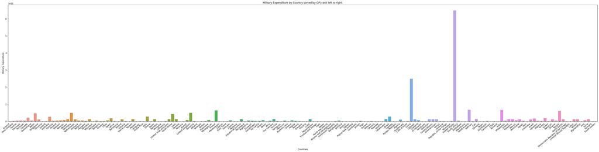

```python
import matplotlib.pyplot as plt
import seaborn as sns

plt.figure(figsize = (50, 10))
plt.title('Military Expenditure by Country sorted by GPI rank left to right.')
bar = sns.barplot(x = 'Country', y ='Military_Expenditure', data = df)
bar.set_xticklabels(bar.get_xticklabels(), rotation=40, ha="right");
bar.set(xlabel='Countries', ylabel='Military Expenditure');
```

Doesn't really seem to show a pattern. One remarkable takeaway is that while the United States spend uncomparable, exorbitant amount of money, it ranks low in the GPI index rank.

This time, we will do regression analysis to see if there are any relationship. We will use Sklearn library to model the regression.

### Effect of GDP on Military Expenditure

One would naturally assume that the wealthier a country, more moeny they spend on defense. Lets confirm if there is any relation between the GDP and Millitary spending using regression analysis.

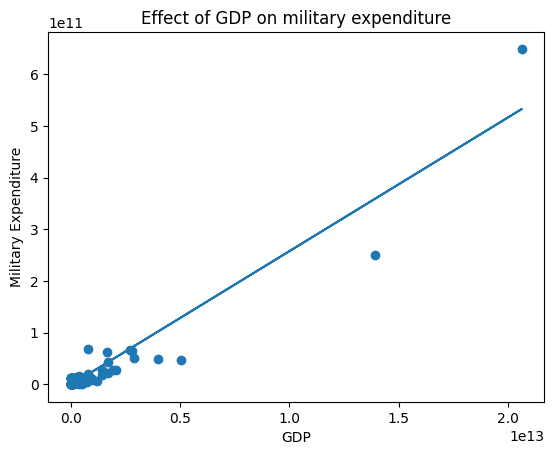

```python
import sklearn
from sklearn.linear_model import LinearRegression, RANSACRegressor
from sklearn.model_selection import train_test_split
from sklearn.metrics import mean_squared_error, r2_score
import numpy as np

x = np.array(df['GDP']).reshape((-1, 1))
y =np.array(df['Military_Expenditure'])

#traning fit using the data.
model = LinearRegression().fit(x, y)
#prediction. traning model input data same for this case..
pred = model.predict(x)


plt.scatter(x,y)
plt.plot(x,pred)
plt.xlabel('GDP')
plt.ylabel('Military Expenditure')
plt.title('Effect of GDP on military expenditure')

plt.show()
```

Lets analysize this more closely.

```python
from statsmodels.formula.api import ols

res = ols(formula='Military_Expenditure~GDP', data=df).fit()
print(res.summary())
```

```
                             OLS Regression Results
================================================================================
Dep. Variable:     Military_Expenditure   R-squared:                       0.909
Model:                              OLS   Adj. R-squared:                  0.909
Method:                   Least Squares   F-statistic:                     1611.
Date:                  Sun, 20 Aug 2023   Prob (F-statistic):           9.43e-86
Time:                          23:14:22   Log-Likelihood:                -4066.9
No. Observations:                   163   AIC:                             8138.
Df Residuals:                       161   BIC:                             8144.
Df Model:                             1
Covariance Type:              nonrobust
==============================================================================
                 coef    std err          t      P>|t|      [0.025      0.975]
------------------------------------------------------------------------------
Intercept  -1.489e+09   1.35e+09     -1.102      0.272   -4.16e+09    1.18e+09
GDP            0.0259      0.001     40.132      0.000       0.025       0.027
==============================================================================
Omnibus:                       70.955   Durbin-Watson:                   2.013
Prob(Omnibus):                  0.000   Jarque-Bera (JB):             5410.936
Skew:                          -0.425   Prob(JB):                         0.00
Kurtosis:                      31.213   Cond. No.                     2.17e+12
==============================================================================

Notes:
[1] Standard Errors assume that the covariance matrix of the errors is correctly specified.
[2] The condition number is large, 2.17e+12. This might indicate that there are
strong multicollinearity or other numerical problems.
```

From looking at the regression analysis, we get the probability of f-statisctic to be near 0 value. There is almost no chance that null hyphothesis of no relationship hold.

Next, we will use RANSAC to model regression. We saw from bar graph that there are some significant outliers in the data. Random sample consensus, or RANSAC, is an iterative method for estimating a mathematical model from a data set that contains outliers. The RANSAC algorithm works by identifying the outliers in a data set and estimating the desired model using data that does not contain outliers. To read furthur on RANSAC. Click [Here](https://www.mathworks.com/discovery/ransac.html#:~:text=What%20Is%20RANSAC%3F,that%20does%20not%20contain%20outliers.)

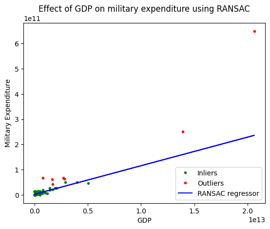

```
Mean squared error: 1161029260639288557568.00
Coefficient of determination: 0.62
```

```python
model_ransac = RANSACRegressor(residual_threshold=20000000000)
model_ransac.fit(x, y)
inlier_mask = model_ransac.inlier_mask_
outlier_mask = np.logical_not(inlier_mask)

# Predict data of estimated models
ransac_pred = model_ransac.predict(x)




plt.plot(x[inlier_mask], y[inlier_mask], '.g', label='Inliers')
plt.plot(x[outlier_mask], y[outlier_mask], '.r', label='Outliers')
plt.plot(x, ransac_pred, '-b', label='RANSAC regressor')
plt.legend(loc='lower right')

plt.xlabel('GDP')
plt.ylabel('Military Expenditure')
plt.title('Effect of GDP on military expenditure using RANSAC')
plt.show()

print('Mean squared error: %.2f' % mean_squared_error(y, ransac_pred))
print('Coefficient of determination: %.2f'% r2_score(y, ransac_pred))
```

From above regressions we do see that there is a positive relationship between GDP and Military Expenditure. Countries are more likely to spend more on military the more GDP they have.

### Total military size per expenditure vs Expenditure

We know that military power is more than just head-count. With development of technology, military expenditure is more than just gearing up a solider. Its about developing and purchasing fighter jets, tanks, various equipments, welfare and more. Some even suggest that with modern warfare, number of soldier does not matter as much. If such is the case, we should see that as military expenditure grow, we should see less soldiers per expenditure as technology can replace headcount to a extent.

[figure not shown]

```python
from numpy import inf

df['Total_Expenditure'] = df['Total']/df['Military_Expenditure']
df.loc[df['Total_Expenditure'] ==inf,'Total_Expenditure'] = 0

x =np.array(df['Military_Expenditure']).reshape(-1,1)
y = np.array((df['Total_Expenditure']))




#traning fit using the data.
model = LinearRegression().fit(x, y)
#prediction. traning model input data same for this case..
pred = model.predict(x)


plt.scatter(x,y)
plt.plot(x,pred)
plt.xlabel('Military Expnditure')
plt.ylabel('Military size per USD')
plt.title('Effect of GDP on military expenditure')

plt.show()
```

```python
res = ols(formula='Total_Expenditure~Military_Expenditure', data=df).fit()
print(res.summary())

df = df.drop(columns=['Total_Expenditure'])
```

```
                            OLS Regression Results
==============================================================================
Dep. Variable:      Total_Expenditure   R-squared:                       0.005
Model:                            OLS   Adj. R-squared:                 -0.001
Method:                 Least Squares   F-statistic:                    0.8046
Date:                Sun, 20 Aug 2023   Prob (F-statistic):              0.371
Time:                        23:16:21   Log-Likelihood:                 994.84
No. Observations:                 163   AIC:                            -1986.
Df Residuals:                     161   BIC:                            -1980.
Df Model:                           1
Covariance Type:            nonrobust
========================================================================================
                           coef    std err          t      P>|t|      [0.025      0.975]
----------------------------------------------------------------------------------------
Intercept                0.0002   4.37e-05      4.794      0.000       0.000       0.000
Military_Expenditure -6.954e-16   7.75e-16     -0.897      0.371   -2.23e-15    8.36e-16
==============================================================================
Omnibus:                      212.461   Durbin-Watson:                   1.865
Prob(Omnibus):                  0.000   Jarque-Bera (JB):             8139.495
Skew:                           5.406   Prob(JB):                         0.00
Kurtosis:                      35.887   Cond. No.                     5.78e+10
==============================================================================

Notes:
[1] Standard Errors assume that the covariance matrix of the errors is correctly specified.
[2] The condition number is large, 5.78e+10. This might indicate that there are
strong multicollinearity or other numerical problems.
```

We have P value of 0.371 We failed to find significant relationship between military spending and military size per USD. Size of the military personel is important regardless of how much a country spends on military.

## GPI Score

Finally lets predict GPI score using all of the features.

```python
X = df.values[:, 1:-1]
y = df.values[:, -1].astype(int)

formula = "GPI_Score ~ Active_military + Reserve_military + Paramilitary + Total + Per1000capita_active + Per1000capita_total + GDP + Military_Expenditure"
reg = ols(formula=formula, data=df).fit()
reg.summary()
```

OLS Regression Results

| Dep. Variable: | GPI_Score | R-squared: | 0.269 |
| --- | --- | --- | --- |
| Model: | OLS | Adj. R-squared: | 0.236 |
| Method: | Least Squares | F-statistic: | 8.168 |
| Date: | Sun, 20 Aug 2023 | Prob (F-statistic): | 1.87e-08 |
| Time: | 23:18:58 | Log-Likelihood: | -96.233 |
| No. Observations: | 163 | AIC: | 208.5 |
| Df Residuals: | 155 | BIC: | 233.2 |
| Df Model: | 7 |  |  |
| Covariance Type: | nonrobust |  |  |

|  | coef | std err | t | P>\|t\| | [0.025 | 0.975] |
| --- | --- | --- | --- | --- | --- | --- |
| Intercept | 1.9874 | 0.048 | 41.656 | 0.000 | 1.893 | 2.082 |
| Active_military | -0.0001 | 3.16e-06 | -40.689 | 0.000 | -0.000 | -0.000 |
| Reserve_military | -0.0001 | 3.12e-06 | -41.741 | 0.000 | -0.000 | -0.000 |
| Paramilitary | -0.0001 | 3.08e-06 | -42.216 | 0.000 | -0.000 | -0.000 |
| Total | 0.0001 | 3.11e-06 | 41.797 | 0.000 | 0.000 | 0.000 |
| Per1000capita_active | 0.0207 | 0.012 | 1.780 | 0.077 | -0.002 | 0.044 |
| Per1000capita_total | -0.0027 | 0.003 | -0.898 | 0.371 | -0.009 | 0.003 |
| GDP | -3.336e-13 | 6.84e-14 | -4.876 | 0.000 | -4.69e-13 | -1.98e-13 |
| Military_Expenditure | 8.088e-12 | 2.2e-12 | 3.680 | 0.000 | 3.75e-12 | 1.24e-11 |

| Omnibus: | 27.647 | Durbin-Watson: | 0.557 |
| --- | --- | --- | --- |
| Prob(Omnibus): | 0.000 | Jarque-Bera (JB): | 37.415 |
| Skew: | 0.984 | Prob(JB): | 7.51e-09 |
| Kurtosis: | 4.280 | Cond. No. | 7.50e+17 |

Notes:  
[1] Standard Errors assume that the covariance matrix of the errors is correctly specified.  
[2] The condition number is large, 7.5e+17. This might indicate that there are  
strong multicollinearity or other numerical problems.

## Feature Importance

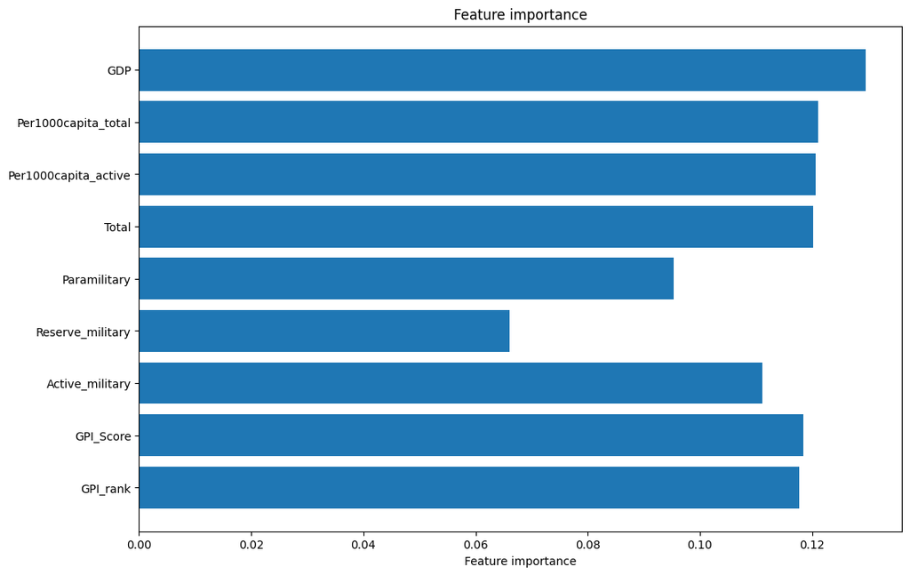

```python
from sklearn.ensemble import RandomForestClassifier
X = df.values[:, 1:-1]
y = df.values[:, -1].astype(int)

clf = RandomForestClassifier()  #using default.  Different creiteria did not seem to change result.
clf = clf.fit(X, y)

plt.figure(figsize=(12, 8))
plt.title('Feature importance')
plt.xlabel('Feature importance')

plt.barh(y=df.columns[1:-1], width=clf.feature_importances_)
plt.show()
```

## Interpretation: Drawing conclusions

We first saw that United States while spending exorbitant amount of money, ranked low in GPI Index.

I don't mean to sound idealistic and military forces are uncessary. For example, we saw that there is a positive relationship between GDP and military expenditure; that a country with More GDP spend more in military. This makes snese as the bigger the economy, more likely it is that the country is mroe active player in the global scene and thus are more likely to interact with other country and come across difference of interests. Military power will give upper hand in not only solving the conflict forcefully but give more power when solving diplomatically. Unless the world suddenly comes together and decides to have no violence whatsoever, military power is crucial to voicing and defending your interests.